# Bayesian inference

Nate Pope

Oct 28, 2016

# Goals

1. How does Bayesian inference work?
2. Computation using Stan and `rstan`
3. Diagnostics/summary using `shinystan`

# Statistical inference in a nutshell

- Data = process + noise
- Statistical inference requires:
  1. A model for the process (**deterministic model**)
  2. A model for the noise (**stochastic model**)

*“All models are wrong, but some are useful”* - George Box

# Maximum likelihood in a nutshell

**Notation:**

$Y$ is data, $\Theta$ are parameters of model

**Likelihood:**

Probability of data given parameters, symbolically $p(Y|\Theta)$

**Maximum likelihood:**

1. Based on model, write down equation for $p(Y|\Theta)$
2. Find parameter values that maximize $p(Y|\Theta)$
3. These values are the “maximum likelihood estimate”

# Maximum likelihood (examp.)

A tiny simulated dataset (line 31):

```r
# simulate some data
set.seed(101)
fake_data <- rnorm(n = 3, mean = 2, sd = 2)
fake_data # look at it
```

```
## [1] 1.3479270 3.1049237 0.6501123
```

**Model:**

$Y$ is normally distributed, with mean $\mu$ and sd $\sigma$

**Notation:**

$$p(Y|\Theta = \{\mu, \sigma\}) = \prod_i (2\pi \sigma^{-2})^{-\frac{1}{2}} e^{-0.5 \frac{(y_i-\mu)^2}{\sigma^2}}$$

# Maximum likelihood (examp.)

A function to implement the likelihood (line 40):

```r
# a function that returns the likelihood
# for given values of mu and sigma
likelihood <- function(mu, sigma, data_values){
    prod( dnorm(data_values, mean = mu, sd = sigma) )
}

# for example ...
likelihood(mu = 0.5, sigma = 0.3, data_values = fake_data)
```

```
## [1] 1.622847e-18
```

# Maximum likelihood (examp.)

Visualized across a grid of values of $\mu$ and $\sigma$:

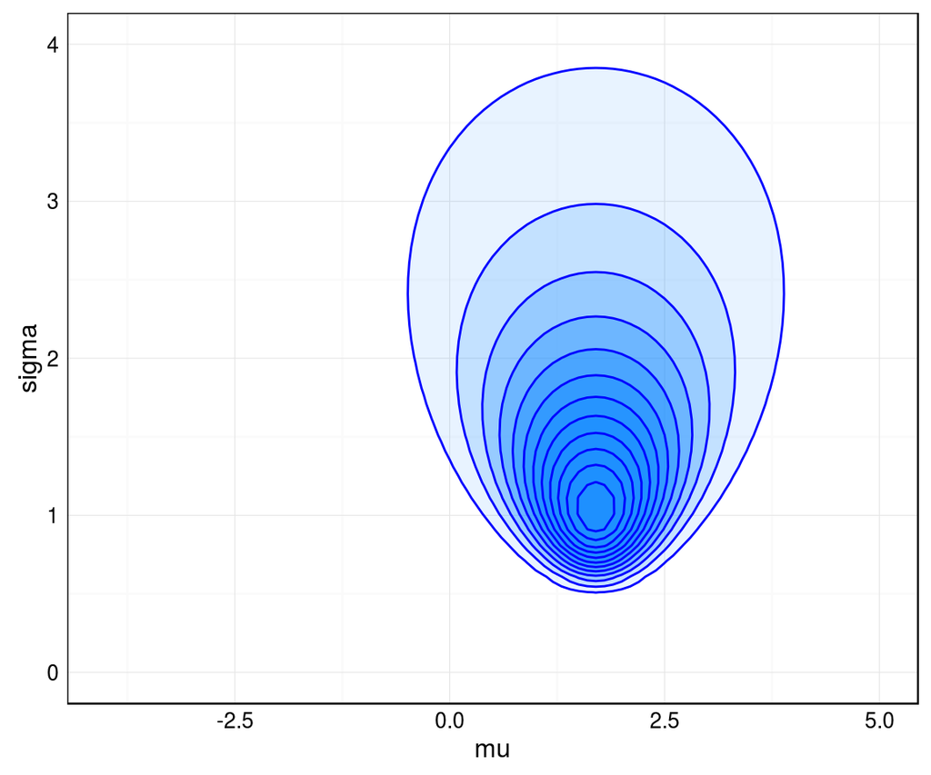

# Bayesian inference in a nutshell

**Goal:**

Probabilities of *possible* parameter values (instead of “single best estimate”)

**Posterior distribution:**

Probability of the parameters given the data, $p(\Theta|Y)$

**Bayesian inference:**

1. Equation for likelihood
2. Equation for prior probability of parameter values
3. Use Bayes’ rule to calculate $p(\Theta|Y)$

# Bayesian inference

**Bayes’ rule:**

A tool to calculate the posterior:

$$p(\Theta|Y) = \dfrac{p(Y|\Theta)p(\Theta)}{p(Y)}$$

- $p(Y|\Theta)$ is called the likelihood
- $p(\Theta)$ is called the prior
- $p(Y)$ is called the marginal likelihood

# Bayesian inference

**Bayes’ rule:**

A tool to calculate the posterior:

$$p(\Theta|Y) \propto p(Y|\Theta)p(\Theta)$$

- Only the numerator is a function of the parameters!
- The posterior is proportional to the likelihood *weighted* by the prior

# Bayesian inference (examp.)

In “normal sample” likelihood, parameters are $\mu$ and $\sigma$.

**Priors:**

**Notation:**

# Bayesian inference

Function to calculate these priors (line 75):

```r
# a function that returns the prior for given values of mu and sigma
prior <- function(mu, sigma){
    # normal prior on mu, half-normal prior on sigma
    dnorm(mu, mean = -1, sd = 1) *
        2*dnorm(abs(sigma), mean = 0, sd = 1)
}

# for example ...
prior(mu = 0.5, sigma = 0.3)
```

```
## [1] 0.09879287
```

# Bayesian inference

Across (same) grid of values of $\mu$ and $\sigma$:

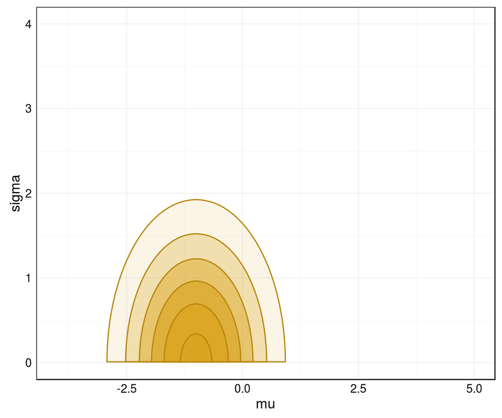

# Bayesian inference

**Numerator of Bayes’ rule:**

- Proportional to posterior distribution
- Has the same “shape” as posterior
- Also called: “target”, “unnormalized posterior”

**Notation (model from before):**

# Bayesian inference

Function to calculate (unnormalized) posterior (line 105):

```r
# a function that computes the unnormalized posterior
# given the functions likelihood(), prior() defined above
posterior <- function(mu, sigma, data_values){
    likelihood(mu, sigma, data_values) * prior(mu, sigma)
}

# for example ...
posterior(0, 0.5, fake_data)
```

```
## [1] 4.15249e-12
```

# Example 1

Prior, unnormalized posterior, likelihood:

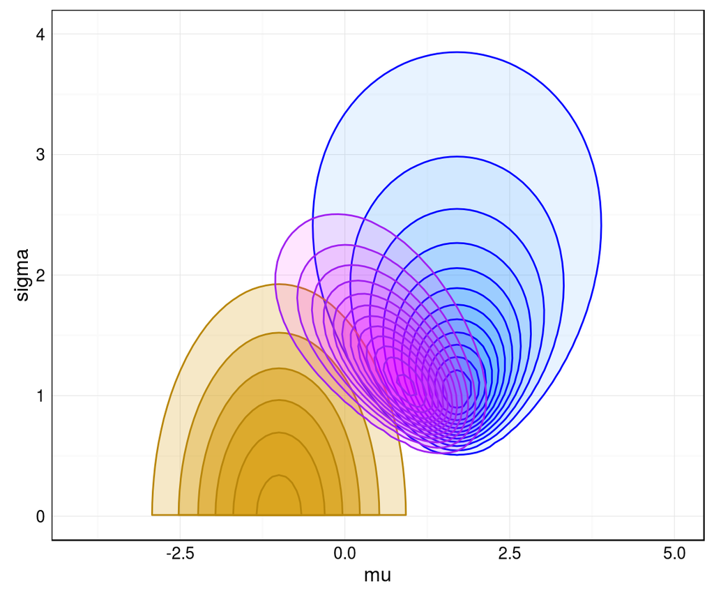

# Exercise 1

# Bayesian inference

**Denominator of Bayes’ rule:**

- The ‘sum’ of unnormalized posterior across possible parameter values
- Makes the posterior sum (integrate) to 1
- Called the **marginal likelihood**

**Notation:**

$$p(Y) = \int p(Y|\Theta) p(\Theta) d\Theta$$

# Bayesian inference

**Conclusions:**

1. Bayes’ rule is used to calculate **posterior** from **likelihood** and **prior**
2. The **likelihood** and **prior** control the shape of the posterior
3. The **marginal likelihood** forces posterior to sum (integrate) to 1
4. As amount of data increases, likelihood dominates posterior

# Why use Bayesian inference?

Three stereotypes:

**(1) Bayesians:**

- Believe that priors are useful, principled
- Like the simplicity, rigor of Bayesian interpretation

**(2) “Get-’er-done”-ers:**

- Like Bayesian computational methods
- Bayes generates more robust predictions, etc.

**(3) Babesians:**

- Think that “Bayesian” sounds sexy and mysterious

# Spectrum of software

**Problem:**

Marginal likelihood (thus posterior) hard to calculate

**Markov chain Monte Carlo (MCMC):**

Approximate posterior with simulation. Implementations:

- **Specific models**: easy to use, efficiency high, flexibility low (ie. MCMCglmm, BayesLogit)
- **Modelling language**: moderate difficulty, efficiency usually high, flexibility high (ie. Stan, JAGS/BUGS, Nimble)
- **Do-it-yourself**: hard to do, efficiency depends, flexibility limitless

# Stan

**Possible Stan workflow:**

1. Write model in Stan’s language (can do within R)
2. Assemble data/inputs into list (in R)
3. Feed to Stan with function `stan()`
4. Look at output with `launch_shinystan()`

# Stan

**Syntax:**

Language is mash-up of R and C++ syntax:

- Lines must end with a semi-colon `;` (C++)
- All variables/parameters must have defined types/dimensions (C++)
- Indexing starts at 1 (R)

# Stan

**Syntax:**

Language is mash-up of R and C++ syntax:

- The “for-loop” syntax is `for(iterator in range) { do stuff }` (R)
- Supports “incrementing operators”: for example, the operator `left_side += right_side` adds `right_side` to `left_side` (C++)
- Lines are commented out by `//` (C++)

# Stan

A Stan model is defined in strict blocks.

```
block_name {
    // do stuff here
}
```

**Essential blocks:**

1. `data {}`
2. `parameters {}`
3. `model {}`

# *data* block

**Purpose:**

For every input, declare:

1. *type*
2. *dimension* (if needed)
3. *boundaries* (optional)
4. *name*

**Type declaration syntax:**

```c
type<lower, upper>[type dimension] name[dimension];
```

# `data` block

**Type declaration examples:**

```
int N; // integer called N

int N[10]; // ten integers

int<lower=0> N[10]; // ten non-negative integers

vector[10] Y; // a vector of reals of length 10

vector[10] Y[5]; // five vectors of reals of length 10
```

# *parameters* block

**Purpose:**

For every **unknown parameter**, declare:

1. *type*
2. *dimension* (if needed)
3. *boundaries* (optional)
4. *name*

**Example:**

An unknown real called `sigma` with a lower bound of 0:

```
real<lower=0> sigma;
```

# *model* block

**Purpose:**

Calculate the log “target”: the log numerator of Bayes’ rule.

**Structure:**

- The “programmy” part of the model code
- Defines how the data and parameters are related, with:
  1. deterministic functions
  2. probability distributions
- **Must** sum the logs of every term in the likelihood and prior

# *model* block

**Important syntax:**

- `target` is a name reserved for the log numerator of Bayes’ rule
- `target` equals 0 at the top of the model block
- Add to `target` with the syntax: `target += something`
- Calculate probability distributions with syntax `log_pdf( variable | parameters )`
- (This will be much more clear with an example.)

# Stan (example model)

A regression problem with data `mtcars`

```r
# we'll use the mtcars data
data(mtcars)
mtcars %>% head
```

```
##                    mpg cyl disp  hp drat    wt  qsec vs am gear carb
## Mazda RX4         21.0   6  160 110 3.90 2.620 16.46  0  1    4    4
## Mazda RX4 Wag     21.0   6  160 110 3.90 2.875 17.02  0  1    4    4
## Datsun 710        22.8   4  108  93 3.85 2.320 18.61  1  1    4    1
## Hornet 4 Drive    21.4   6  258 110 3.08 3.215 19.44  1  0    3    1
## Hornet Sportabout 18.7   8  360 175 3.15 3.440 17.02  0  0    3    2
## Valiant           18.1   6  225 105 2.76 3.460 20.22  1  0    3    1
```

# Stan (example model)

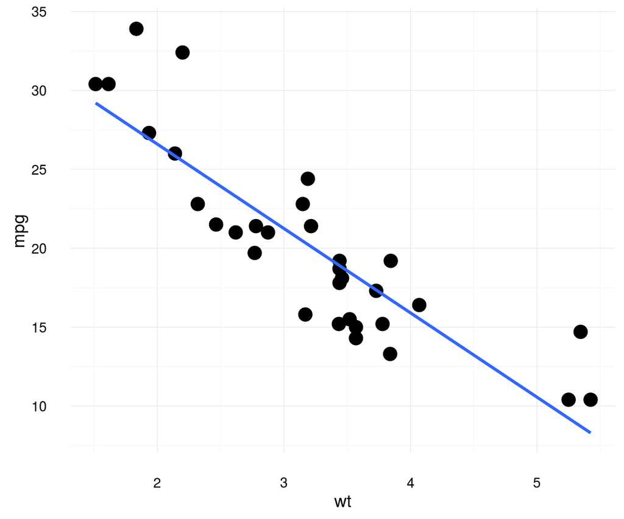

```r
# regression of miles per gallon against weight
mtcars %>% ggplot(aes(x=wt,y=mpg)) +
    geom_point(size=4) + geom_smooth(method="lm", se=F) +
    theme_minimal()
```

# Stan (example model)

**Definitions:**

Let $y$ be `mtcars$mpg`. Let $x$ be `mtcars$wt`. Let $\alpha, \beta$ be the intercept and slope. Let $\sigma$ be the residual sd. Let $N$ be the number of data points.

**Model:**

For the $i$th data point, $y_i$ is normally distributed with mean $\alpha + \beta x_i$ and sd $\sigma$.

**Notation:**

$$y_i \sim \mathrm{Normal}( \alpha + \beta x_i, \sigma )$$

# Stan (example model)

Let’s move to R …